# Project I

# Problem 1: Logistic Regression

## Introduction

We analyized the Cookie data where a certain group of children go door to door (with adult supervision) selling cookies. They predicited if a household would buy cookies or not by using the household’s income (found with adult supervision). It contained two columns:

Column 1: `Y`: Takes on the value 1 if the group sold cookies, and 0 otherwise.

Column 2: `X`: The income of the household, in thousands of dollars.

## Summary

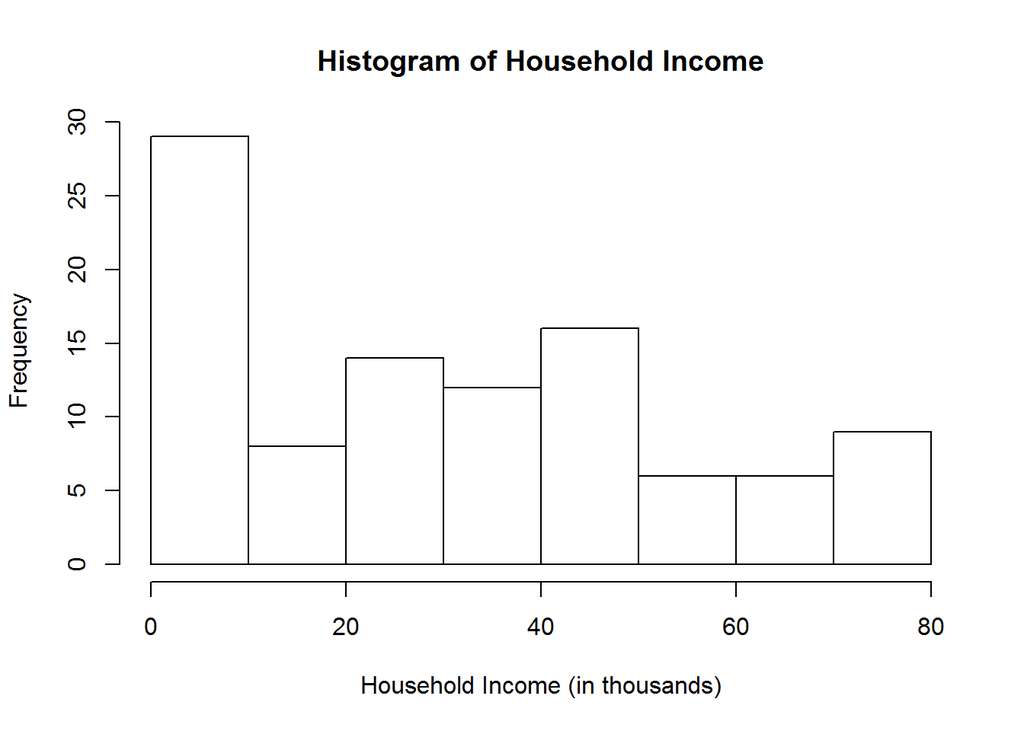

In the Cookie data, most households have an income between $0 to $10,000, with a maximum of $70,000 to $80,000.

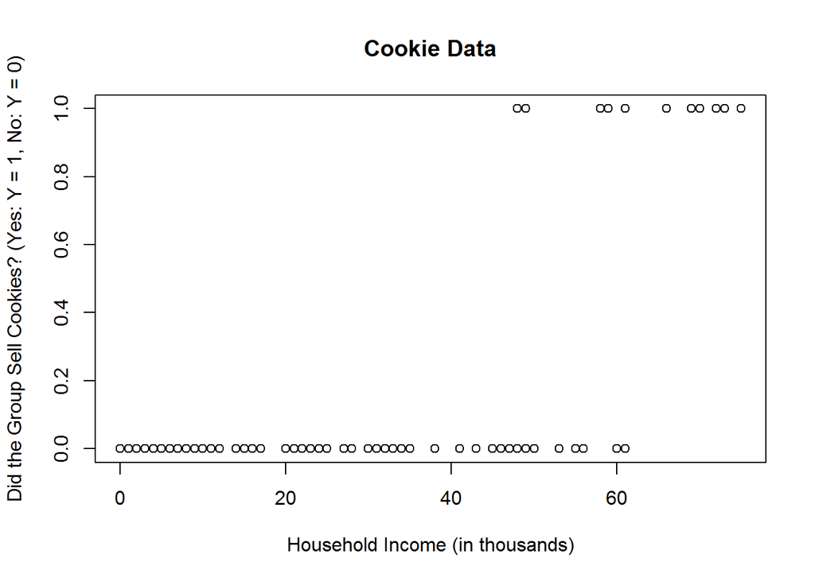

The estimated regression function is: $logit(\hat{\pi}) = -12.72177 + (0.22386)x$

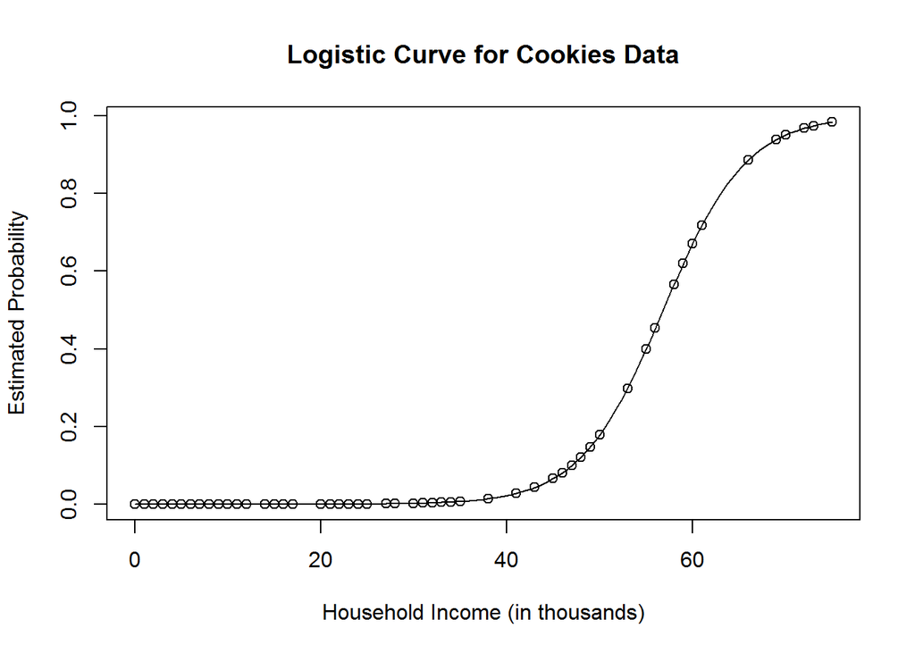

According to our plot, since the slope begins to be very steep at $x = 40$, it appears that household income does have an effect on whether you will purchase cookies or not starting at an income of $40,000 and up.

## Analysis

We will be testing the hypothesis:

$H_{0}: \beta_{1} = 0$ vs $H_{a}: \beta_{1} \neq 0$

The Likelihood Ratio test-statistic is: 70.54732

The Wald test-statistic is: 3.620512

The Likelihood Ratio p-value is: 4.493567e-17

The Wald p-value is: 0.00029402

The probability of buying cookies for 0.50 is 56.81912 (household income: $56,800).

## Interpretation

If in reality household income has no effect on whether or not the subject would buy cookies, the probability of observing out data or more extreme is 0.00029402/4.493567e-17 = 0.0.

Since both the p-values for Likelihood Ratio and Wald are smaller than any reasonable $\alpha = 0.1, 0.01, 0.05$, we reject $H_{0}: \beta_{1} = 0$. Therefore, we conclude there is a relationship between household income and the probability of the subject buying cookies.

The sign of $\hat{\beta_{1}}$ for this data set is positive, it suggests the probability of buying cookies increases as household income does.

Our data contains household incomes that are $0 (in other words, 0 is included in the data), which means that $\hat{\alpha}$ has a practical interpretation.

## Conclusion

The odds of buying cookies are multiplied by $e^{0.2239} = 1.250945$ for every one thousand dollar increase in household income. Or, when household income increases by one thousand dollars, the odds of buying cookies are 1.250945 times what they were previously.

# Problem 2: Log-Linear Models

## Summary

We analyzed the IQshort data. This data has information on the frequency of extreme IQs (high or low), extreme age groups (young is under 25, old is over 50), and gender. It contains the columns:

Column 1: `X`: Age category (`Young, Old`)

Column 2: `Y`: Gender (`Male, Female`)

Column 3: `Z`: IQ Category (`High, Low`)

Column 4: `Freq`: The count for the particular row combination

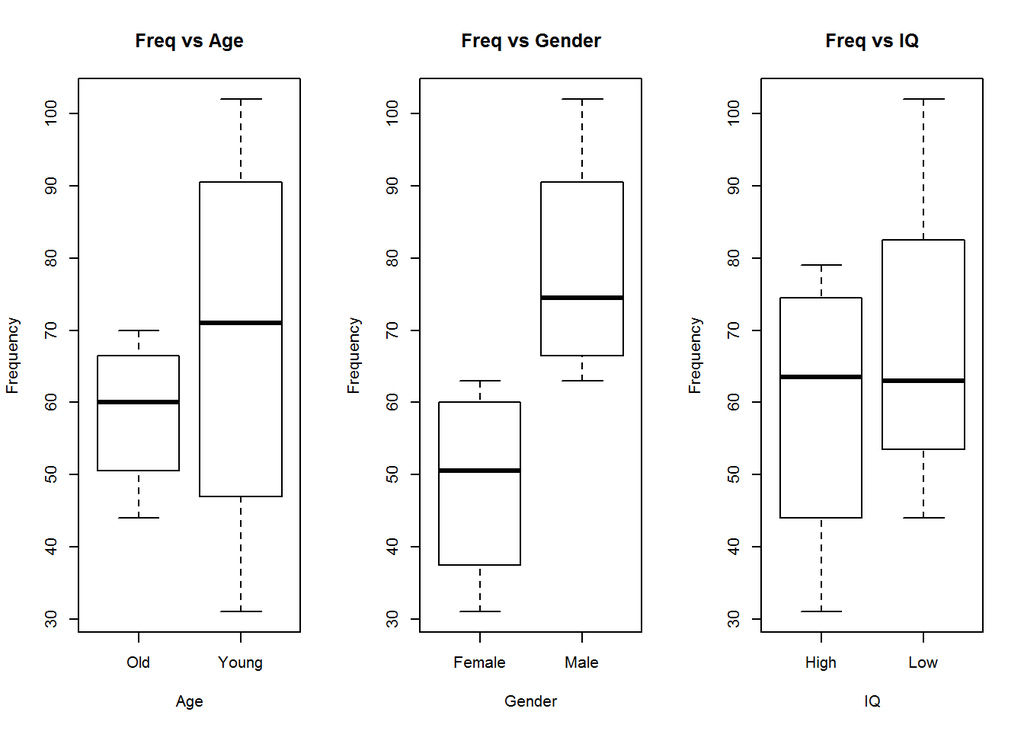

## Analysis

The model with the smallest AIC (excluding the saturated model) is (XY, XZ), $F \sim X+Y+Z+X*Y+X*Z$. In other words, the model that is conditionally independent given $X$.

$ln(\mu_{ijk}) = \lambda + \lambda^{X}_{i} + \lambda^{Y}_{j} + \lambda^{Z}_{k} + \lambda^{XY}_{ij} + \lambda^{XZ}_{ik}$

We used the AIC criteria because AIC takes into account the number of parameters.

The estimated values are:

$\lambda = 4.0039865$, $\lambda^{X}_{i} = -0.3769824$, $\lambda^{Y}_{j} = 0.2752286$, $\lambda^{Z}_{k} = -0.1713583$, $\lambda^{XY}_{ij} = 0.3799736$, $\lambda^{XZ}_{ik} = 0.5768234$

Looking at the model, it is clear that there is dependence between Age and Gender and Age and IQ. To be thorough, we will also be using a hypothesis test to check for dependence.

We will test the hypothesis:

$H_{0}$: The smaller (current) model fits better.

$H_{a}$: The larger (saturated) model fits better.

The Likelihood Ratio Test Statistic has a p-value of 0.5874443.

Based on the p-value of 0.5874443, for any reasonable $\alpha = 0.01, 0.05, 0.1$ we would fail to reject $H_{0}$ because the p-value is larger than any reasonable $\alpha$.

The confidence interval for the interaction term of $(X,Y)$ is $(e^{0.02130284}, e^{0.74021576}) = (1.02153, 2.09639)$. The odds of being young if male are between 1.02153 and 2.09639 times that of being young if female at 95% confidence.

The confidence interval for the interaction term of $(X,Z)$ is $(e^{0.22536306}, e^{0.93110843}) = (1.25278, 2.53732)$. The odds of being young if low IQ are between 1.25278 and 2.53732 times that of being young if high IQ at 95% confidence.

## Interpretation

Since we failed to reject $H_{0}$, we have enough evidence to conclude that the the current model of $F \sim X+Y+Z+X*Y+X*Z$ with interaction terms $(X,Y), (X,Z)$ fits well.

Since the interaction term $\lambda^{XY}_{ij}$ exists in the model, this suggest there is a dependence between age and gender. Additionally, since the interaction term $\lambda^{XZ}_{ik}$ exists in the mode, this suggest there is a dependence between age and IQ category.

## Conclusion

We conclude that the current model $F \sim X+Y+Z+X*Y+X*Z$ fits well. This means that the categories $(X,Y)$, age and gender are dependent on each other and the categories $(X,Z)$, age and IQ are dependent on each other.

### Appendix

```r
cookie = read.csv("Cookie.csv")
hist(cookie$X, main = "Histogram of Household Income",
     xlab = "Household Income (in thousands)")
plot(Y ~ X, cookie, main = "Cookie Data",
     xlab = "Household Income (in thousands)",
     ylab = "Did the Group Sell Cookies? (Yes: Y = 1, No: Y = 0)")
logit.model = glm(Y ~ X, family = binomial(logit), data = cookie)
summary(logit.model)
plot(cookie$X,logit.model$fitted.values,
     main = "Logistic Curve for Cookies Data",
     ylab = "Estimated Probability",
     xlab = "Household Income (in thousands)")
curve(predict(logit.model, data.frame(X=x), type="response"), add=TRUE)
alpha = 0.05
confint(logit.model,level = (1-alpha))

summary(logit.model)$coefficients[2,]
#LB Test-Stat
smaller.model = glm(Y ~ 1, family = binomial(logit), data = cookie)
LR = as.numeric(-2*(logLik(smaller.model) - logLik(logit.model)))
LR

#Wald Test-stat
wald.ts = summary(logit.model)$coefficients[2,3]
wald.ts
#p-value for LR
d.f. = length(logit.model$coefficients) - length(smaller.model$coefficients)
p.val.LR = pchisq(LR, d.f.,lower.tail = FALSE)
p.val.LR

#p-value for Wald
wald.pval = round(summary(logit.model)$coefficients[2,4],8)
wald.pval
#prob = 0.5
X_50 = -(-12.7218)/0.2239
X_50
IQ = read.csv("IQShort.csv")
xtabs(F ~ X + Y + Z, IQ)
par(mfrow=c(1,3))

plot(F ~ X, IQ, main = "Freq vs Age",
     ylab = "Frequency", xlab = "Age")
plot(F ~ Y, IQ, main = "Freq vs Gender",
     ylab = "Frequency", xlab = "Gender")
plot(F ~ Z, IQ, main = "Freq vs IQ",
     ylab = "Frequency", xlab = "IQ")
all.model.formulas = c("F~X+Y+Z","F~X+Y+Z+Y*Z","F~X+Y+Z+X*Z",
                       "F~X+Y+Z+X*Y","F~X+Y+Z+X*Y+X*Z",
                       "F~X+Y+Z+X*Y+Y*Z","F~X+Y+Z+X*Z+Y*Z",
                       "F~X+Y+Z+X*Y+X*Z+Y*Z",
                       "F~X+Y+Z+X*Y+X*Z+Y*Z+X*Y*Z")
all.model.fits = lapply(all.model.formulas,function(the.model){
  glm(the.model,data = IQ, family = poisson)
})

good.fit.LL = function(the.model){
  K = length(the.model$coefficients)
  df.model = length(the.model$residuals) - K
  Pearson.TS = sum(residuals(the.model,type = "pearson")^2)
  LL = as.numeric(logLik(the.model))
  Dev = as.numeric(-2*LL)
  the.AIC = AIC(the.model)
  the.BIC = BIC(the.model)
  pval = pchisq(round(Pearson.TS,4),df.model,lower.tail = F)
  All.GOF = c(Dev,Pearson.TS,df.model,K,pval,the.AIC,the.BIC)
  names(All.GOF) = c("Deviance","Pearson",
                     "df.model","num.para",
                     "p-val:Pear","AIC","BIC")
  return(All.GOF)
}

all.GOF = sapply(all.model.fits,function(the.model){
  good.fit.LL(the.model)
}) #It is the wrong orientation so I flip it
all.GOF = t(all.GOF)
#I also add the model formulas for reference
rownames(all.GOF) = all.model.formulas
round(all.GOF,digits =4)

book.notation = c("(X,Y,Z)","(X,YZ)","(Y,XZ)",
                  "(Z,XY)","(XY,XZ)","(XY,YZ)",
                  "(XZ,YZ)","(XY,XZ,YZ)","(XYZ)")
rownames(all.GOF) = book.notation
round(all.GOF,digits = 4)

#best model is (XY, XZ) aka F~X+Y+Z+X*Y+X*Z (conditionally independent)
Model = glm(F ~ X + Y + Z + X*Y + X*Z, data = IQ, family = poisson(link = log))
summary(Model)$coefficients
Model.sat = glm(F ~ X + Y + Z + X*Y + X*Z + Y*Z, data=IQ,family = poisson) #Fully saturdated two-way table
LS =  logLik(Model.sat) # Log-likelihood of saturated model
ps = length(Model.sat$coefficients) # of parameters for saturated model
Model.current = glm(F ~ X + Y + Z + X*Y + X*Z, data=IQ,family = poisson) #Whatever model we are interested in
LM = logLik(Model.current) # Log-likelihood of current model
pm = length(Model.current$coefficients) # of parameters for current model
Dev = as.numeric(-2*(LM-LS)) #The deviance, or LR test-statistic
d.f. = ps-pm
pval.LR = pchisq(Dev,d.f.)
alpha = 0.05
Model.current = glm(F~X+Y+Z+X*Y+X*Z, data=IQ,family = poisson)
round(confint(Model.current,level = 1-alpha),6)
```